# Assignment_4_Meenu_Ravi_part1

## Assignment 4, Meenu Ravi

### April 30 2021

```python
import sys
import sklearn
import pandas as pd
import numpy as np
import os
import warnings
from sklearn.datasets import fetch_openml
from sklearn.pipeline import Pipeline
from sklearn.preprocessing import StandardScaler
from sklearn.decomposition import PCA
from sklearn.metrics import accuracy_score
import time
warnings. filterwarnings("ignore")
# to make this notebook's output stable across runs
np.random.seed(42)
from sklearn.model_selection import train_test_split
from sklearn.ensemble import RandomForestClassifier
%matplotlib inline
import matplotlib as mpl
import matplotlib.pyplot as plt
from sklearn.manifold import MDS
from sklearn.manifold import LocallyLinearEmbedding
from sklearn.manifold import TSNE
from sklearn.manifold import Isomap
from sklearn.cluster import KMeans
from sklearn.model_selection import StratifiedShuffleSplit
from sklearn.datasets import fetch_olivetti_faces
from sklearn.datasets import make_blobs
from sklearn.metrics import silhouette_score
from operator import itemgetter
```

### Question 1: 15 points

#### - Load the MNIST dataset and split it into a training set and a test set: take the first 60,000 instances for training, and the remaining 10,000 for testing.

```python
mnist = fetch_openml('mnist_784', version=1, as_frame=False)
X, y = mnist["data"], mnist["target"]
X_train, X_test, y_train, y_test = X[:60000], X[60000:], y[:60000], y[60000:] # the data is already shuffled
```

```python
print(X_train.shape)
print(y_test.shape)
```

```
(60000, 784)
(10000,)
```

#### - Train a Random Forest classifier on the dataset and time how long it takes, then evaluate the resulting model on the test set.

```python
t0 = time.time()
rnd_clf = RandomForestClassifier(n_estimators=10, random_state=42)
rnd_clf.fit(X_train, y_train)
t1 = time.time()

total = t1-t0
print(str(total)+" secs taken")
```

```
4.936229228973389 secs taken
```

```python
y_pred_rf = rnd_clf.predict(X_test)
```

```python
accuracy_score(y_test, y_pred_rf)
```

```
0.9492
```

#### - Next, use PCA to reduce the dataset’s dimensionality, with an explained variance ratio of 95%.

```python
pca = PCA()
pca.fit(X_train)
cumsum = np.cumsum(pca.explained_variance_ratio_)
d = np.argmax(cumsum >= 0.95) + 1
d
```

```
154
```

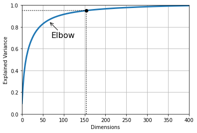

```python
plt.figure(figsize=(6,4))
plt.plot(cumsum, linewidth=3)
plt.axis([0, 400, 0, 1])
plt.xlabel("Dimensions")
plt.ylabel("Explained Variance")
plt.plot([d, d], [0, 0.95], "k:")
plt.plot([0, d], [0.95, 0.95], "k:")
plt.plot(d, 0.95, "ko")
plt.annotate("Elbow", xy=(65, 0.85), xytext=(70, 0.7),
             arrowprops=dict(arrowstyle="->"), fontsize=16)
plt.grid(True)

plt.show()
```

```python
pca = PCA(n_components=154)
X_reduced = pca.fit_transform(X_train)
```

```python
X_reduced.shape
```

```
(60000, 154)
```

#### - Train a new Random Forest classifier on the reduced dataset and see how long it takes.

```python
t0 = time.time()
rnd_clf = RandomForestClassifier(n_estimators=10, random_state=42)
rnd_clf.fit(X_reduced, y_train)
t1 = time.time()

total = t1-t0
print(str(total)+" secs taken")
```

```
12.208563327789307 secs taken
```

#### - Was training much faster?

The time taken on the training set when PCA was done was not faster. It took about 5 seconds with the original dataset and 12 seconds with the dimensions reduced. This shows that random forest classifier algorithm is not the most time efficient for this dataset and we should try a new classifier algorithm to achieve better time results

#### - Next, evaluate the classifier on the test set. How does it compare to the previous classifier?

```python
X_test_reduced = pca.transform(X_test)
y_pred_rf = rnd_clf.predict(X_test_reduced)
```

```python
accuracy_score(y_test, y_pred_rf)
```

```
0.8953
```

Compared to the random forest classifier on the original dataset, the dimensionality reduced random forest classifier is less accurate. It looses around 5% accuracy. It is probably because when we reduce the dimensionality, we are considereing only dimensions that make up 95% of the variance, so some variance gets lost.

### Question 2: 15 points

#### Use t-SNE to reduce the MNIST dataset down to two dimensions and plot the result using Matplotlib. You can use a scatterplot using 10 different colors to represent each image’s target class. Alternatively, you can replace each dot in the scatterplot with the corresponding instance’s class (a digit from 0 to 9), or even plot scaled-down versions of the digit images themselves (if you plot all digits, the visualization will be too cluttered, so you should either draw a random sample or plot an instance only if no other instance has already been plotted at a close distance). You should get a nice visualization with well-separated clusters of digits

```python
mnist = fetch_openml('mnist_784', version=1, as_frame=False)
X, y = mnist["data"], mnist["target"]
```

```python
random_indices = np.random.choice(X.shape[0], size=1000, replace=False)
```

```python
X_rand = X[random_indices]
X_rand.shape
```

```
(1000, 784)
```

```python
y_rand = y[random_indices]
y_rand.shape
```

```
(1000,)
```

```python
tsne = TSNE(n_components=2, random_state=42)
X_reduced_tsne = tsne.fit_transform(X_rand)
```

```python
y_rand = [int(i) for i in y_rand]
```

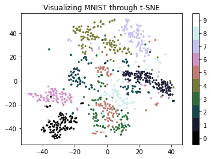

```python
plt.scatter(X_reduced_tsne[:, 0], X_reduced_tsne[:, 1], s= 5, c=y_rand,cmap=plt.cm.get_cmap('cubehelix', 10))
plt.colorbar(boundaries=np.arange(11)-0.5).set_ticks(np.arange(10))
plt.title('Visualizing MNIST through t-SNE');
```

#### Try using other dimensionality reduction algorithms such as PCA, LLE, or MDS and compare the resulting visualizations.

```python
lle = LocallyLinearEmbedding(n_components=2, n_neighbors=10, random_state=42)
X_reduced = lle.fit_transform(X_rand)
```

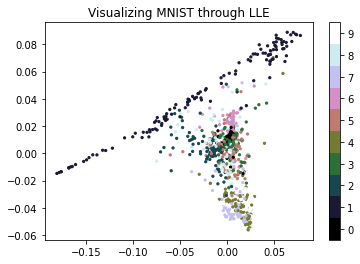

```python
plt.scatter(X_reduced[:, 0], X_reduced[:, 1], s= 5, c=y_rand,cmap=plt.cm.get_cmap('cubehelix', 10))
plt.colorbar(boundaries=np.arange(11)-0.5).set_ticks(np.arange(10))
plt.title('Visualizing MNIST through LLE');
```

```python
mds = MDS(n_components=2, random_state=42)
X_reduced_mds = mds.fit_transform(X_rand)
```

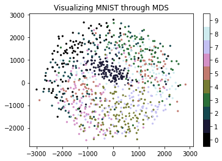

```python
plt.scatter(X_reduced_mds[:, 0], X_reduced_mds[:, 1], s= 5, c=y_rand,cmap=plt.cm.get_cmap('cubehelix', 10))
plt.colorbar(boundaries=np.arange(11)-0.5).set_ticks(np.arange(10))
plt.title('Visualizing MNIST through MDS');
```

```python
isomap = Isomap(n_components=2)
X_reduced_isomap = isomap.fit_transform(X_rand)
```

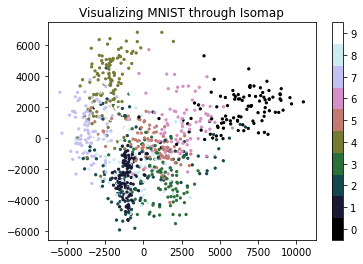

```python
plt.scatter(X_reduced_isomap[:, 0], X_reduced_isomap[:, 1], s= 5, c=y_rand,cmap=plt.cm.get_cmap('cubehelix', 10))
plt.colorbar(boundaries=np.arange(11)-0.5).set_ticks(np.arange(10))
plt.title('Visualizing MNIST through Isomap');
```

The best visualization seems to be the tsne one because you can clearly see the different group of number labels. The other methods show vialuals where the labels kind of overlap.

### Question 3: 15 points

#### The classic Olivetti faces dataset contains 400 grayscale 64×64pixel images of faces. Each image is flattened to a 1D vector of size 4,096. 40 different people were photographed (10 times each), and the usual task is to train a model that can predict which person is represented in each picture.

#### Load the dataset using the sklearn.datasets.fetch_olivetti_faces() function, then split it into a training set, a validation set, and a test set (note that the dataset is already scaled between 0 and 1). Since the dataset is quite small, you probably want to use stratified sampling to ensure that there are the same number of images per person in each set.

```python
olivetti = fetch_olivetti_faces()
```

```
downloading Olivetti faces from https://ndownloader.figshare.com/files/5976027 to C:\Users\meenu\scikit_learn_data
```

```python
X, y = olivetti["data"], olivetti["target"]
```

```python
print(X.shape)
print(y.shape)
```

```
(400, 4096)
(400,)
```

```python
strat_split = StratifiedShuffleSplit(n_splits=1, test_size=40, random_state=42)
train_valid_idx, test_idx = next(strat_split.split(X, y))
X_train_valid = olivetti.data[train_valid_idx]
y_train_valid = olivetti.target[train_valid_idx]

X_test = olivetti.data[test_idx]
y_test = olivetti.target[test_idx]

strat_split = StratifiedShuffleSplit(n_splits=1, test_size=80, random_state=43)
train_idx, valid_idx = next(strat_split.split(X_train_valid, y_train_valid))
X_train = X_train_valid[train_idx]
y_train = y_train_valid[train_idx]
X_valid = X_train_valid[valid_idx]
y_valid = y_train_valid[valid_idx]
```

```python
X_train.shape
```

```
(280, 4096)
```

#### Next, cluster the images using K-Means, and ensure that you have a good number of clusters using silhouette score.

```python
kmeans_per_k = [KMeans(n_clusters=k, random_state=42).fit(X_train)
                for k in range(1, 280,10)]
```

```python
silhouette_scores = [silhouette_score(X_train, model.labels_)
                     for model in kmeans_per_k[1:]]
```

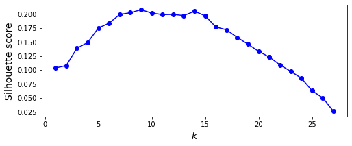

```python
plt.figure(figsize=(8, 3))
plt.plot(range(1, len(silhouette_scores)+1), silhouette_scores, "bo-")
plt.xlabel("$k$", fontsize=14)
plt.ylabel("Silhouette score", fontsize=14)
plt.show()
```

```python
maxi=0
ctr=1
bestk=0
for i in silhouette_scores:
    if i>maxi:
        maxi=i

for i in silhouette_scores:
    if i==maxi:
        bestk=ctr
    ctr+=1
print(bestk,maxi)
```

```
9 0.20734496
```

```python
best_model=kmeans_per_k[bestk]
best_model
```

```
KMeans(n_clusters=91, random_state=42)
```

#### Visualize the clusters: do you see similar faces in each cluster?

```
Cluster 0
```

```
Cluster 1
```

```
Cluster 2
```

```
Cluster 3
```

```
Cluster 4
```

```
Cluster 5
```

```
Cluster 6
```

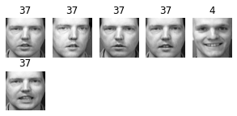

```
Cluster 7
```

```
Cluster 8
```

```
Cluster 9
```

```
Cluster 10
```

```
Cluster 11
```

```
Cluster 12
```

```
Cluster 13
```

```
Cluster 14
```

```
Cluster 15
```

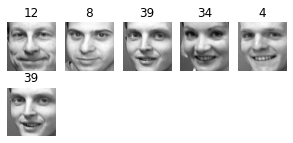

```
Cluster 16
```

```
Cluster 17
```

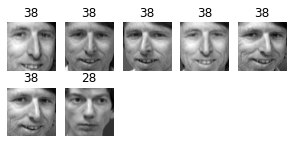

```
Cluster 18
```

```
Cluster 19
```

```
Cluster 20
```

```
Cluster 21
```

```
Cluster 22
```

```
Cluster 23
```

```
Cluster 24
```

```
Cluster 25
```

```
Cluster 26
```

```
Cluster 27
```

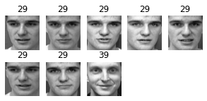

```
Cluster 28
```

```
Cluster 29
```

```
Cluster 30
```

```
Cluster 31
```

```
Cluster 32
```

```
Cluster 33
```

```
Cluster 34
```

```
Cluster 35
```

```
Cluster 36
```

```
Cluster 37
```

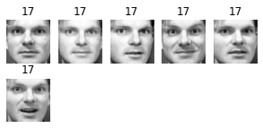

```
Cluster 38
```

```
Cluster 39
```

```
Cluster 40
```

```
Cluster 41
```

```
Cluster 42
```

```
Cluster 43
```

```
Cluster 44
```

```
Cluster 45
```

```
Cluster 46
```

```
Cluster 47
```

```
Cluster 48
```

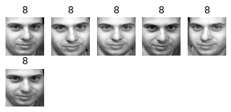

```
Cluster 49
```

```
Cluster 50
```

```
Cluster 51
```

```
Cluster 52
```

```
Cluster 53
```

```
Cluster 54
```

```
Cluster 55
```

```
Cluster 56
```

```
Cluster 57
```

```
Cluster 58
```

```
Cluster 59
```

```
Cluster 60
```

```
Cluster 61
```

```
Cluster 62
```

```
Cluster 63
```

```
Cluster 64
```

```
Cluster 65
```

```
Cluster 66
```

```
Cluster 67
```

```
Cluster 68
```

```
Cluster 69
```

```
Cluster 70
```

```
Cluster 71
```

```
Cluster 72
```

```
Cluster 73
```

```
Cluster 74
```

```
Cluster 75
```

```
Cluster 76
```

```
Cluster 77
```

```
Cluster 78
```

```
Cluster 79
```

```
Cluster 80
```

```
Cluster 81
```

```
Cluster 82
```

```
Cluster 83
```

```
Cluster 84
```

```
Cluster 85
```

```
Cluster 86
```

```
Cluster 87
```

```
Cluster 88
```

```
Cluster 89
```

```
Cluster 90
```

```python
def plot_faces(faces, labels, n_cols=5):
    n_rows = (len(faces) - 1) // n_cols + 1
    plt.figure(figsize=(n_cols, n_rows * 1.1))
    for index, (face, label) in enumerate(zip(faces, labels)):
        plt.subplot(n_rows, n_cols, index + 1)
        plt.imshow(face.reshape(64, 64), cmap="gray")
        plt.axis("off")
        plt.title(label)
    plt.show()

for cluster_id in np.unique(best_model.labels_):
    print("Cluster", cluster_id)
    in_cluster = best_model.labels_==cluster_id
    faces = X_train[in_cluster].reshape(-1, 64, 64)
    labels = y_train[in_cluster]
    plot_faces(faces, labels)
```

### Question 4: 15 points

#### Continuing with the Olivetti faces dataset, train a classifier to predict which person is represented in each picture, and evaluate it on the validation set.

```python
rnd_clf = RandomForestClassifier(n_estimators=280, random_state=42)
rnd_clf.fit(X_train, y_train)
```

```
RandomForestClassifier(n_estimators=280, random_state=42)
```

```python
rnd_clf.score(X_valid, y_valid)
```

```
0.925
```

#### Next, use K-Means as a dimensionality reduction tool, and train a classifier on the reduced set.

```python
X_train_reduced = best_model.transform(X_train)
X_valid_reduced = best_model.transform(X_valid)
X_test_reduced = best_model.transform(X_test)
```

```python
rnd_clf = RandomForestClassifier(n_estimators=280, random_state=42)
rnd_clf.fit(X_train_reduced, y_train)
```

```
RandomForestClassifier(n_estimators=280, random_state=42)
```

```python
rnd_clf.score(X_valid_reduced, y_valid)
```

```
0.8125
```

This accuracy score is worse than when we didn't dimensionally reduce

#### Search for the number of clusters that allows the classifier to get the best performance: what performance can you reach?

```python
clusters=[]
for n in range(1, 281,10):
    pipeline = Pipeline([
        ("kmeans", KMeans(n_clusters=n, random_state=42)),
        ("forest_clf", RandomForestClassifier(n_estimators=280, random_state=42))
    ])
    pipeline.fit(X_train_reduced, y_train)
    clusters.append((n, pipeline.score(X_valid_reduced, y_valid)))
    print(n, pipeline.score(X_valid_reduced, y_valid))
```

```
1 0.075
11 0.425
21 0.5
31 0.55
41 0.5625
51 0.6
61 0.625
71 0.6375
81 0.625
91 0.625
101 0.6375
111 0.6
121 0.625
131 0.6125
141 0.6125
151 0.5875
161 0.6
171 0.625
181 0.6375
191 0.6
201 0.625
211 0.575
221 0.6375
231 0.6125
241 0.6125
251 0.625
261 0.6375
271 0.625
```

```python
maxi=0
ctr=0
max_ind=0
for i in clusters:
    if i[1]>maxi:
        maxi=i[1]
        max_ind=ctr
    ctr+=1
print(clusters[max_ind])
```

```
(71, 0.6375)
```

I reached an accuracy rate of 64% when I tried with the reduced set.

```python
clusters=[]
for n in range(1, 281,10):
    pipeline = Pipeline([
        ("kmeans", KMeans(n_clusters=n, random_state=42)),
        ("forest_clf", RandomForestClassifier(n_estimators=280, random_state=42))
    ])
    pipeline.fit(X_train, y_train)
    clusters.append((n, pipeline.score(X_valid, y_valid)))
    print(n, pipeline.score(X_valid, y_valid))
```

```
1 0.075
11 0.65
21 0.7375
31 0.775
41 0.825
51 0.8
61 0.775
71 0.7875
81 0.775
91 0.8125
101 0.7875
111 0.875
121 0.85
131 0.8
141 0.8125
151 0.825
161 0.85
171 0.8625
181 0.825
191 0.8125
201 0.8375
211 0.825
221 0.8125
231 0.825
241 0.8375
251 0.8375
261 0.8375
271 0.8375
```

```python
maxi=0
ctr=0
max_ind=0
for i in clusters:
    if i[1]>maxi:
        maxi=i[1]
        max_ind=ctr
    ctr+=1
print(clusters[max_ind])
```

```
(111, 0.875)
```

With the original train set, I received an accuracy of 87.5%.

#### What if you append the features from the reduced set to the original features (again, searching for the best number of clusters)?

```python
X_train_appended = np.c_[X_train, X_train_reduced]
X_valid_appended  = np.c_[X_valid, X_valid_reduced]
X_test_appended  = np.c_[X_test, X_test_reduced]
```

```python
clusters=[]
for n in range(1, 281,10):
    pipeline = Pipeline([
        ("kmeans", KMeans(n_clusters=n, random_state=42)),
        ("forest_clf", RandomForestClassifier(n_estimators=280, random_state=42))
    ])
    pipeline.fit(X_train_appended, y_train)
    clusters.append((n, pipeline.score(X_valid_appended, y_valid)))
    print(n, pipeline.score(X_valid_appended, y_valid))
```

```
1 0.0625
11 0.5
21 0.5625
31 0.6
41 0.6375
51 0.65
61 0.65
71 0.6125
81 0.6125
91 0.6875
101 0.65
111 0.6375
121 0.6625
131 0.6625
141 0.675
151 0.6875
161 0.675
171 0.65
181 0.6375
191 0.65
201 0.6625
211 0.6625
221 0.6875
231 0.65
241 0.6625
251 0.675
261 0.6625
271 0.7
```

```python
maxi=0
ctr=0
max_ind=0
for i in clusters:
    if i[1]>maxi:
        maxi=i[1]
        max_ind=ctr
    ctr+=1
print(clusters[max_ind])
```

```
(271, 0.7)
```

The accuracy rate I achieved with the appended data is 70%. It is still not the best